# Reproducible Research: Peer Assessment 1

```r
library(ggplot2)
library(dplyr)
```

## Decompressing Data

To start the analysis, and since data has already been included in the current repository, but it’s compressed in a zip file, we’ll start by decompressing the file.

```r
file_name <- "activity.zip"
dest_file <- file.path("./", file_name)
unzip(dest_file)
```

## Loading and preprocessing the data

The next step is to load the data from the uncompressed file.

```r
act_data <- read.csv("activity.csv")
```

## Summary on the data

```r
dim(act_data)
```

```
## [1] 17568     3
```

```r
head(act_data)
```

```
##   steps       date interval
## 1    NA 2012-10-01        0
## 2    NA 2012-10-01        5
## 3    NA 2012-10-01       10
## 4    NA 2012-10-01       15
## 5    NA 2012-10-01       20
## 6    NA 2012-10-01       25
```

### Summary

```r
summary(act_data)
```

```
##      steps                date          interval
##  Min.   :  0.00   2012-10-01:  288   Min.   :   0.0
##  1st Qu.:  0.00   2012-10-02:  288   1st Qu.: 588.8
##  Median :  0.00   2012-10-03:  288   Median :1177.5
##  Mean   : 37.38   2012-10-04:  288   Mean   :1177.5
##  3rd Qu.: 12.00   2012-10-05:  288   3rd Qu.:1766.2
##  Max.   :806.00   2012-10-06:  288   Max.   :2355.0
##  NA's   :2304     (Other)   :15840
```

As we can observe there are 2304 NA values or missing values in our step column data. Let’s see how much percentage of our data is missing:

```r
mean(is.na(act_data$steps))
```

```
## [1] 0.1311475
```

```r
act_data_no_nas <- act_data[complete.cases(act_data), ]
head(act_data_no_nas)
```

```
##     steps       date interval
## 289     0 2012-10-02        0
## 290     0 2012-10-02        5
## 291     0 2012-10-02       10
## 292     0 2012-10-02       15
## 293     0 2012-10-02       20
## 294     0 2012-10-02       25
```

## What is mean total number of steps taken per day?

Now, let’s take a look at some of the descritive analysis we can get from the data, starting with the number of steps taken per day:

```r
steps_per_day <- aggregate(
    x = act_data_no_nas$steps,
    by = list(day = as.factor(act_data_no_nas$date)),
    FUN = sum
)
```

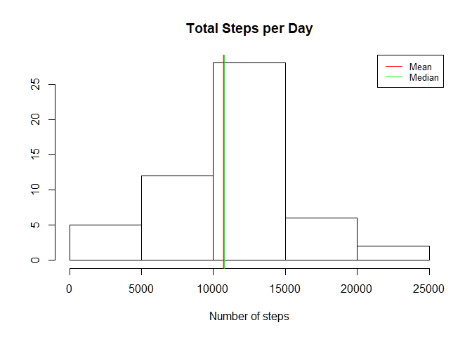

```r
steps_mean = mean(steps_per_day$x)
steps_median = median(steps_per_day$x)

hist(
    steps_per_day$x,
    main = "Total Steps per Day",
    ylab = "",
    xlab = "Number of steps"
)

abline(v = steps_mean, col = "red", lwd = 2)
abline (v = steps_median, col = "green")

legend(
    "topright",
    legend = c("Mean", "Median"),
    col = c("red", "green"),
    lty = 1,
    cex = 0.8
)
```

## What is the average daily activity pattern?

```r
act_data_no_nas$date <- as.Date(act_data_no_nas$date)
steps_by_interval <-
    aggregate(act_data_no_nas$steps ~ act_data_no_nas$interval, FUN = mean)
```

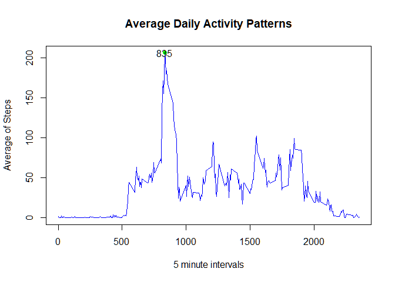

```r
plot(
    steps_by_interval$`act_data_no_nas$interval`,
    steps_by_interval$`act_data_no_nas$steps`,
    type = "l",
    ylab = "Average of Steps",
    xlab = "5 minute intervals",
    main = "Average Daily Activity Patterns",
    col = "blue"
)

max_interval <- which.max(steps_by_interval$`act_data_no_nas$steps`)
max_x <- steps_by_interval$`act_data_no_nas$interval`[max_interval]
max_y <- max(steps_by_interval$`act_data_no_nas$steps`)

points(max_x,max_y,col="green", pch=16)
text(max_x, max_y,labels = max_x)
```

Here we see that the time with the most activity or number of steps on average per day is 835, that 8:35am.

## Imputing missing values

Note that there are a number of days/intervals where there are missing values. The presence of missing days may introduce bias into some calculations or summaries of the data, so we’ll be imputing for values for those missing data:

The total number of missing values is 2304.

```r
act_data_imputted <- act_data

for (i in 1:length(act_data_imputted$steps)) {
    if (is.na(act_data_imputted$steps[i])) {
        current_interval <- act_data_imputted$interval[i]
        replace_interval <-
            which(steps_by_interval$`act_data_no_nas$interval` == current_interval)

        act_data_imputted$steps[i] <-
            steps_by_interval$`act_data_no_nas$steps`[replace_interval]
    }
}
```

Let’s now check for the difference plotting the new dataset:

```r
imputted_steps_per_day <- aggregate(
    x = act_data_imputted$steps,
    by = list(day = as.factor(act_data_imputted$date)),
    FUN = sum
)
```

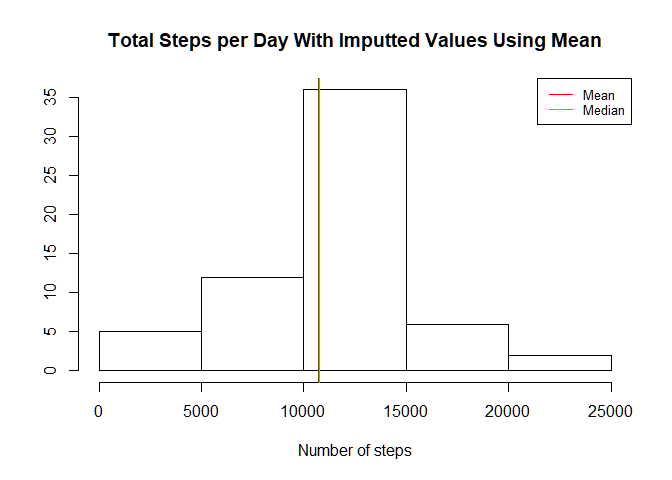

```r
imputted_steps_mean = mean(imputted_steps_per_day$x)
imputted_steps_median = median(imputted_steps_per_day$x)

hist(
    imputted_steps_per_day$x,
    main = "Total Steps per Day With Imputted Values Using Mean",
    ylab = "",
    xlab = "Number of steps"
)

abline(v = imputted_steps_mean, col = "red", lwd = 2)
abline (v = imputted_steps_median, col = "green")

legend(
    "topright",
    legend = c("Mean", "Median"),
    col = c("red", "green"),
    lty = 1,
    cex = 0.8
)
```

Here we may have a similar distribution, which didn’t make a huge impact on the data.

## Are there differences in activity patterns between weekdays and weekends?

Using the filled-in missing values for this part, we’re going to crate a new column in the dataset identifying if the activity was performed on a weekday or the weekend:

```r
wend <- c("Sat", "Sun")

act_data_imputted <-
    mutate(act_data_imputted,
       weekday = as.factor(ifelse(
           weekdays(as.Date(act_data_imputted$date), abbreviate = T) %in% wend,
           yes = "weekend",
           no = "weekday"
       )))

head(act_data_imputted)
```

```
##       steps       date interval weekday
## 1 1.7169811 2012-10-01        0 weekday
## 2 0.3396226 2012-10-01        5 weekday
## 3 0.1320755 2012-10-01       10 weekday
## 4 0.1509434 2012-10-01       15 weekday
## 5 0.0754717 2012-10-01       20 weekday
## 6 2.0943396 2012-10-01       25 weekday
```

First, let’s split data for weekday and weekend.

```r
splitted <- split(act_data_imputted, act_data_imputted$weekday)
```

```r
i_weekday_by_interval <-
    aggregate(splitted$weekday$steps ~ splitted$weekday$interval, FUN = mean)

i_weekend_by_interval <-
    aggregate(splitted$weekend$steps ~ splitted$weekend$interval, FUN = mean)
```

Now let’s plot data:

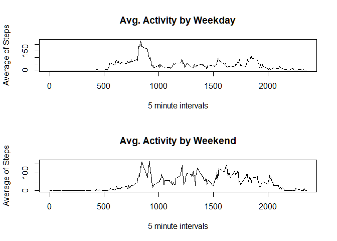

```r
par(mfrow=c(2,1))

plot(
    i_weekday_by_interval$`splitted$weekday$interval`,
    i_weekday_by_interval$`splitted$weekday$steps`,
    type = "l",
    ylab = "Average of Steps",
    xlab = "5 minute intervals",
    main = "Avg. Activity by Weekday"
)

plot(
    i_weekend_by_interval$`splitted$weekend$interval`,
    i_weekend_by_interval$`splitted$weekend$steps`,
    type = "l",
    ylab = "Average of Steps",
    xlab = "5 minute intervals",
    main = "Avg. Activity by Weekend"
)
```

Here, it seems subject is more active during weekends than weekdays, especially after 10am.